# Computer Assignment #5 Phase #1

## Ali Hamzehpour 810100129

## Neural Networks and Deep Learning

### Problem Description

This phase consists of two part. In the first part we're asked to code a feed-forward neural network from scratch and use it to classify a data with 2 features(draw a border to classify white and black dots.). In the second part, we have to make a neural network using Pytorch library and use it to train IMDB dataset for classifying positive and negative reviews. We also need to use NLTK tools to preprocess text data before training our network.

## MLP from scratch

### 1. MLP in numpy

$$Sigmoid(x) = \frac{1}{1+e^{-x}} $$

So their derivatives will be:

$$ReLU'(x) = \begin{cases} 1 & \text{if } x \geq 0 \\ 0 & \text{if } x < 0 \\ \end{cases}$$$$Sigmoid \ '(x) = Sigmoid(x) \times (1 - Sigmoid(x)) $$

Now, for each activation class I define a `forward` method that calculates the activation function's output and a `backward` function that calculates the backward step of the activation function. First, it computes the derivative and then multiplies it with the gradient of the next layer.

```python
import numpy as np

class MyReLU(object):
    def forward(self, x):
        self.out = np.maximum(x, 0)
        return self.out

    def backward(self, grad_output):
        return np.where(self.out > 0, grad_output, 0)

    def step(self, learning_rate):
        pass

class MySigmoid(object):
    def forward(self, x):
        self.out = np.reciprocal(1 + np.exp(-x))
        return self.out

    def backward(self, grad_output):
        return grad_output * self.out * (1 - self.out)

    def step(self, learning_rate):
        pass
```

I tested these activation functions to make sure it works correctly:

```python
test_relu = MyReLU()
test_relu.forward([0, -1, 0.5, -0.5, 0.8, 1])
```

```
array([0. , 0. , 0.5, 0. , 0.8, 1. ])
```

It's correct because it gives 0 for negative inputs and returns the input for non-negative inputs.

```python
test_relu.backward(np.ones(1))
```

```
array([0., 0., 1., 0., 1., 1.])
```

```python
test_sig = MySigmoid()

test_sig.forward(np.ones(1))
```

```
array([0.73105858])
```

```python
test_sig.backward(np.ones(1))
```

```
array([0.19661193])
```

Sigmoid output is also OK.

### Linear Layer

Next, We have to implement our linear layer. Each layer consists of two parameters:

- Weights: is a matrix with the shape `(output_size, input_size)`.
- Bias: is a matrix with the shape `(output_size, 1)`.

In `forward` function, the output is calculated as below:

$$ \vec{Z} = \vec{X} \cdot \vec{W} + \vec{B}$$

which $X$ is the input of the layer.

The backward step is calculated as below:

$$ \begin{cases} \frac{\partial{Z}}{\partial{W}} = X \\ \\ \frac{\partial{loss}}{\partial{Z}} = GradientOutput \\ \end{cases} \Longrightarrow \frac{\partial{loss}}{\partial{W}} = GradientOutput \cdot X^\intercal $$$$ \begin{cases} \frac{\partial{Z}}{\partial{B}} = 1 \\ \\ \frac{\partial{loss}}{\partial{Z}} = GradientOutput \\ \end{cases} \Longrightarrow \frac{\partial{loss}}{\partial{B}} = GradientOutput $$$$ \frac{\partial{loss}}{\partial{X}} = \frac{\partial{loss}}{\partial{Z}} \cdot \frac{ \partial{Z}}{\partial{X}} = W^\intercal \cdot GradientOutput $$

And in the step function we simply update our bias and weights:

$$ W_{new} = W_{old} - \alpha \frac{\partial{loss}}{\partial{W}} $$$$ B_{new} = B_{old} - \alpha \frac{\partial{loss}}{\partial{B}} $$

which $\alpha$ is the learning rate.

```python
class MyLinear(object):
    def __init__(self, n_input, n_output):
        self.weights = np.random.randn(n_output, n_input)
        self.bias = np.random.randn(n_output, 1)

    def forward(self, x):
        self.input = x
        return self.weights @ x + self.bias

    def backward(self, grad_output):
        self.grad_weights = grad_output @ self.input.T
        self.grad_bias = np.sum(grad_output, axis=1, keepdims=True)

        grad_input = self.weights.T @ grad_output
        return grad_input

    def step(self, learning_rate):
        self.weights -= learning_rate * self.grad_weights
        self.bias -= learning_rate * self.grad_bias
```

### Feed-forward Neural Network

Now, we have to make the `Sequential` class which is basically the feed-forward neural network. It gets a list of layers and saves them as the layers of the network. In `forward` method, each layer's forward function is called and the output is given to the next layer. In `backward`, back-propagation is implemented. Starting from the last layer, Each layer's backward function is called and the output is given to the previous layer. The loss function is the BCE(Binary Cross-Entropy) which is defined as below:

$$ loss(output, label) = -[label \times log(output) + (1-label) \times log(1-output)]$$

and

$$ \frac{\partial{output}}{\partial{loss}} = \frac{output - label}{output \times (1-output)} $$

and this is what we give as input to the last layer in backward function.

The BCE loss function penalizes the model more heavily when it predicts a wrong class with high confidence, and less heavily when it predicts a wrong class with low confidence.  
I also added a small constant when output is 0 or 1 to avoid division by zero or $log(0)$.

```python
class Sequential(object):
    def __init__(self, layers):
        self.layers = layers

    def forward(self, x):
        cur_out = x
        for layer in self.layers:
            cur_out = layer.forward(cur_out)
        return cur_out

    def compute_loss(self, out, label):
        if out == 0:
            out = 1e-10
        elif out == 1:
            out = out - 1e-10
        loss = -(label * np.log(out) + (1-label) * np.log(1-out))
        self.grad_output = (out - label)/(out*(1 - out))
        return loss

    def backward(self):
        cur_grad = self.grad_output
        for layer in reversed(self.layers):
            cur_grad = layer.backward(cur_grad)

    def step(self, learning_rate):
        for layer in self.layers:
            layer.step(learning_rate)
```

I wrote a `train` function that gets a model and train data then trains the model on it. Epochs show how many times We iterate through whole data. In each data, We calculate the output of the network then calculate the loss function and finally do back-propagation and update the network.

```python
import matplotlib.pyplot as plt

def train(model, X, Y, epochs = 10, learning_rate = 1e-2):
    losses = []
    for epoch in range(epochs):
        loss_sum = 0
        for it in range(len(X)):
            idx = np.random.randint(0, len(X))
            x = X[idx]
            x = x.reshape(2, 1)
            label = Y[idx]
            out = model.forward(x)
            loss_sum += model.compute_loss(out, label)
            model.backward()
            model.step(learning_rate)
        losses.append(loss_sum)
    plot_losses(losses)
    return model

def plot_losses(losses):
    losses = np.array(losses)
    losses = losses.reshape((-1, 1))
    #%matplotlib inline
    plt.plot(losses)
    plt.show()
```

### Data

I made a dictionary of patterns to test them on my models. We have 3 patterns:

- Moons
- Circles
- Spiral

With `choose_pattern` function we can choose our pattern and plot it.

**Note**: I used `plygdata` library to import spiral data. If you don't have it, comment that part.

```python
import pandas as pd
import plygdata as pg
from sklearn.datasets import make_moons, make_circles#, make_classification

def make_spiral():
    data_array = np.array(pg.generate_data(pg.DatasetType.ClassifySpiralData, 0.0))
    X = data_array[:,:-1]
    Y = data_array[:,-1]
    Y = (Y + 1)/2
    return X, Y

def plot_data(ax, X, Y):
    plt.axis('off')
    ax.scatter(X[:, 0], X[:, 1], s=1, c=Y, cmap='bone')

patterns = {
    "moons": make_moons(n_samples=2000, noise=0.1),
    "circles": make_circles(n_samples=2000, noise=0.01),
    "spiral": make_spiral(),
}

def choose_pattern(pattern_name):
    X, Y = patterns[pattern_name]
    x_min, y_min = np.min(X, axis=0)
    x_max, y_max = np.max(X, axis=0)
    fig, ax = plt.subplots(1, 1, facecolor='#4B6EA9', figsize=(7, 7))
    ax.set_xlim(x_min, x_max)
    ax.set_ylim(y_min, y_max)
    plot_data(ax, X, Y)
    plt.show()
    return X, Y
```

`plot_decision_boundry` gets a classifier model and plots the pattern with the border that the classifier makes.

```python
def plot_decision_boundary(X, Y, classifier):
    fig, ax = plt.subplots(1, 1, facecolor='#4B6EA9')
    x_min, y_min = np.min(X, axis=0)
    x_max, y_max = np.max(X, axis=0)
    ax.set_xlim(x_min, x_max)
    ax.set_ylim(y_min, y_max)
    xx, yy = np.meshgrid(np.arange(x_min, x_max, .1),
                     np.arange(y_min, y_max, .1))
    to_forward = np.array(list(zip(xx.ravel(), yy.ravel())))

    Z = classifier.forward(to_forward.T)
    Z = Z.reshape(xx.shape)

    ax.contourf(xx, yy, Z>0.5, cmap='Blues')
    plot_data(ax, X,Y)
    fig.canvas.draw()
```

### Testing

Now we make models for each pattern and see the result:

#### Moons

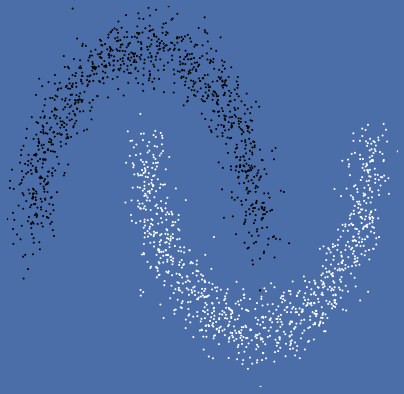

```python
X, Y = choose_pattern("moons")
```

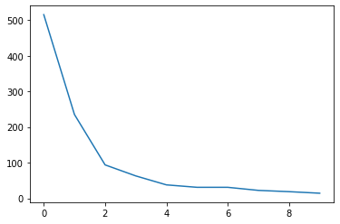

```python
NEURONS = 8
model = Sequential([
    MyLinear(2, NEURONS),
    MyReLU(),
    MyLinear(NEURONS, NEURONS),
    MyReLU(),
    MyLinear(NEURONS, 1),
    MySigmoid()
])
model = train(model, X, Y)
```

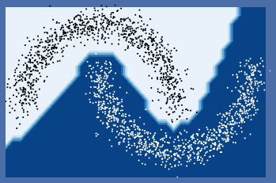

```python
plot_decision_boundary(X, Y, model)
```

#### Circles

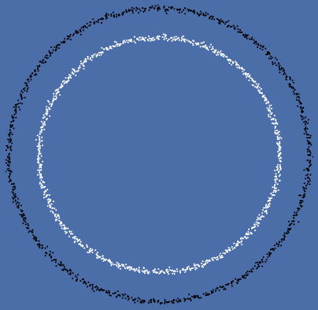

```python
X, Y = choose_pattern("circles")
```

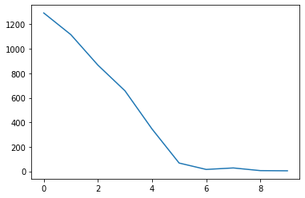

```python
NEURONS = 8
model = Sequential([
    MyLinear(2, NEURONS),
    MyReLU(),
    MyLinear(NEURONS, NEURONS),
    MyReLU(),
    MyLinear(NEURONS, NEURONS),
    MyReLU(),
    MyLinear(NEURONS, 1),
    MySigmoid()
])

model = train(model, X, Y)
```

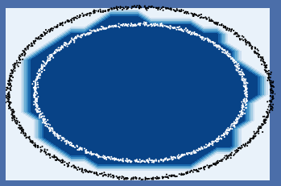

```python
plot_decision_boundary(X, Y, model)
```

#### Spiral

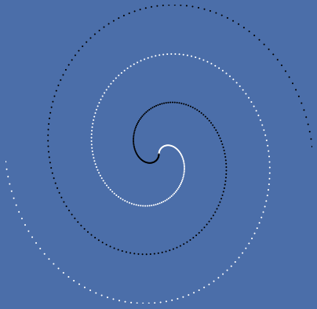

```python
X, Y = choose_pattern("spiral")
```

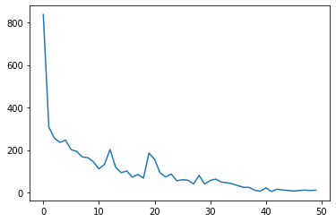

```python
NEURONS = 16
model = Sequential([
    MyLinear(2, NEURONS),
    MyReLU(),
    MyLinear(NEURONS, NEURONS),
    MyReLU(),
    MyLinear(NEURONS, NEURONS),
    MyReLU(),
    MyLinear(NEURONS, 1),
    MySigmoid()
])

model = train(model, X, Y, epochs=50)
```

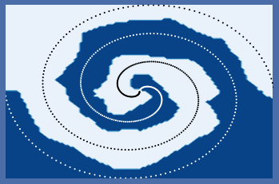

```python
plot_decision_boundary(X, Y, model)
```

## IMDB dataset with Pytorch

### Preprocessing

First, we load the data and call some functions to get a general understanding of the dataset. These dataset consists of reviews in IMDB site about movies and each review is labeled as `positive` or `negative` and our task is to train a model to predict the label of a review.

```python
import pandas as pd
import numpy as np

data = pd.read_csv("imdb_dataset.csv")
```

```python
data.head(10)
```

|  | review | sentiment |
| --- | --- | --- |
| 0 | One of the other reviewers has mentioned that ... | positive |
| 1 | A wonderful little production. <br /><br />The... | positive |
| 2 | I thought this was a wonderful way to spend ti... | positive |
| 3 | Basically there's a family where a little boy ... | negative |
| 4 | Petter Mattei's "Love in the Time of Money" is... | positive |
| 5 | Probably my all-time favorite movie, a story o... | positive |
| 6 | I sure would like to see a resurrection of a u... | positive |
| 7 | This show was an amazing, fresh & innovative i... | negative |
| 8 | Encouraged by the positive comments about this... | negative |
| 9 | If you like original gut wrenching laughter yo... | positive |

```python
data.info()
```

```
<class 'pandas.core.frame.DataFrame'>
RangeIndex: 50000 entries, 0 to 49999
Data columns (total 2 columns):
 #   Column     Non-Null Count  Dtype
---  ------     --------------  -----
 0   review     50000 non-null  object
 1   sentiment  50000 non-null  object
dtypes: object(2)
memory usage: 781.4+ KB
```

The data has no missing values so we don't have to handle that.

```python
data.describe()
```

|  | review | sentiment |
| --- | --- | --- |
| count | 50000 | 50000 |
| unique | 49582 | 2 |
| top | Loved today's show!!! It was a variety and not... | positive |
| freq | 5 | 25000 |

We give each unique label a number to encode our labels.

```python
from sklearn.preprocessing import LabelEncoder

le = LabelEncoder()
data["sentiment"] = le.fit_transform(data["sentiment"])
```

```python
data["sentiment"]
```

```
0        1
1        1
2        1
3        0
4        1
        ..
49995    1
49996    0
49997    0
49998    0
49999    0
Name: sentiment, Length: 50000, dtype: int32
```

Now we split the data to test and train. Test size is 20% of the whole data.

```python
from sklearn.model_selection import train_test_split
X_train, X_test, y_train, y_test = train_test_split(data['review'], data['sentiment'], test_size=0.2)
```

We show a random positive review and a random negative review from both train and test data:

```python
positive_train_reviews = np.array(X_train[y_train == 1])
negative_train_reviews = np.array(X_train[y_train == 0])
print("positive review:")
print(positive_train_reviews[np.random.randint(0, len(positive_train_reviews))])
print("negative review:")
print(negative_train_reviews[np.random.randint(0, len(negative_train_reviews))])
```

```
positive review:
Very funny film. Classic film funny Eddie Murphy of the 80s. I saw when I was a child and I have a good memory. The classic irony of Murphy does not fail, the film is funny, well done. Murphy in the'80s made many films of action that represented for him a way to joke about everything that is dangero…
negative review:
I saw this recently with my wife and discovered it's better than Caine believes, although it's not much cop. Britain's greatest ever screen actor does not seem too interested in this role, which is a pity as he might have elevated it with more conviction in his playing. Rex Harrison seems even less …
```

```python
positive_train_reviews = np.array(X_test[y_test == 1])
negative_train_reviews = np.array(X_test[y_test == 0])
print("positive review:")
print(positive_train_reviews[np.random.randint(0, len(positive_train_reviews))])
print("negative review:")
print(negative_train_reviews[np.random.randint(0, len(negative_train_reviews))])
```

```
positive review:
Saw this film the first time in 1953 with my older brother. It was one of the great 3 Demension films released in that era. We saw it at least thirteen times and were proud of it. Scott does a typical western shoot em up job while surrounded by the Indian arrows rather than surround sound. Oh, for t…
negative review:
They've shown i twice in a very short time now here in Sweden and I am so very tired of it. The bad acting isn't enough... The story itself is so boring and the effects hardly exists. I love the original from 1953 so I recommend you to go and rent that one instead. Because this one is such a bore.
```

We also plot the number of negative and positive data and as you can see, the ratio between positives and negatives are similar in both train and test.

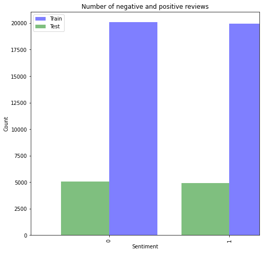

```python
import matplotlib.pyplot as plt
train_counts = y_train.value_counts()
test_counts = y_test.value_counts()
fig, ax = plt.subplots()
train_counts.plot.bar(ax=ax, color='blue', alpha=0.5, width=0.4, position=0, label='Train', figsize=(8, 8))
test_counts.plot.bar(ax=ax, color='green', alpha=0.5, width=0.4, position=1, label='Test')
ax.set_title('Number of negative and positive reviews')
ax.set_xlabel('Sentiment')
ax.set_ylabel('Count')
ax.legend()
plt.show()
```

As you probably noticed in the previous cells, The data is not clean(for example some of the reviews include HTML tags!) and we have to normalize so our model can train better and gain better understandings. We also need to convert the text data to a numerical matrix because the neural network works with numbers. We use **TD_IDF** to convert our data to a numerical matrix.

#### TD_IDF

TF-IDF is a method used to evaluate the importance of words in a document or corpus. It assigns a weight to each word based on its frequency (TF) in the document and its rarity (IDF) in the corpus. Words with high TF-IDF weights are considered to be more important or informative than words with low TF-IDF weights, and are often used for tasks such as text classification, information retrieval, and keyword extraction.

Before vectorization, We can use Lemmatization or Stemming to replace the words with their base form:

- `Lemmatization` is the process of reducing a word to its base or dictionary form, which is known as a lemma. It is often used in natural language processing to group together different forms of a word so that they can be analyzed as a single item.
- `Stemming` is the process of reducing a word to its root or stem form, by removing its suffix. It is often used in natural language processing to reduce words to their most basic form, in order to improve text analysis and information retrieval.

I used Lemmatization for the data. I also used Regex to delete html tags and punctuation marks from the texts.

```python
from sklearn.feature_extraction.text import TfidfVectorizer
from nltk import word_tokenize
from nltk.stem import WordNetLemmatizer
from nltk.corpus import stopwords
import nltk
import re

nltk.download('punkt')
nltk.download('wordnet')
stop_words = set(stopwords.words('english'))

class LemmaTokenizer:
    ignore_tokens = [',', '.', ';', ':', '"', '``', "''", '`']
    def __init__(self):
        self.wnl = WordNetLemmatizer()
    def __call__(self, doc):
        doc = re.sub(r'[^\w\s]', '', doc)
        doc = re.sub(r'<[^>]+>', '', doc)
        return [self.wnl.lemmatize(t) for t in word_tokenize(doc) if t not in self.ignore_tokens]

tokenizer=LemmaTokenizer()
token_stop = tokenizer(' '.join(stop_words))
vectorizer = TfidfVectorizer(max_features=3000,stop_words=token_stop, tokenizer=tokenizer)
vectorizer.fit(X_train.values)
X_train_vec = vectorizer.transform(X_train.values)
X_test_vec = vectorizer.transform(X_test.values)
```

Now we check if the values of the output matrix are between 0 and 1. If the features were not between 0 and 1, these problems could happen:

- If the features have large numerical values, the gradient can become very large or very small, which can cause the learning algorithm to converge slowly or not at all.
- When the input features have different ranges, some features may dominate the learning process, leading to a model that is overly sensitive to those features and does not generalize well to new data
- Some activation functions, such as the sigmoid function, saturate when the input is too large or too small. This means that the output of the activation function approaches either 0 or 1, limiting the ability of the model to learn from the input features

```python
(X_train_vec.min() >= 0 and X_train_vec.max() <= 1) and (X_test_vec.min() >= 0 and X_test_vec.max() <= 1)
```

```
True
```

### MLP in Pytorch

I wrote a linear layer like I did in the first part of the project but this time I inherited `torch.nn.Module` so I didn't need to code `backward` or `step` functions because nn.Module does the optimization on its own. I initialized Weights with [Kaiming-uniform distribution](https://towardsdatascience.com/weight-initialization-in-neural-networks-a-journey-from-the-basics-to-kaiming-954fb9b47c79) and Bias with Unifrom distribution from $-\frac{1}{\sqrt{input size}}$ to $\frac{1}{\sqrt{input \ size}}$.

```python
import torch
import torch.nn as nn
import math

class MyLinear_mod(nn.Module):
    def __init__(self, n_input, n_output):
        super(MyLinear_mod, self).__init__()
        self.weights = nn.Parameter(torch.empty((n_output, n_input)))
        self.bias = nn.Parameter(torch.empty(n_output))
        nn.init.kaiming_uniform_(self.weights, a=math.sqrt(5))
        bound = 1 / math.sqrt(n_input)
        nn.init.uniform_(self.bias, -bound, bound)

    def forward(self, x):
        return x.matmul(self.weights.t()) + self.bias

class MyReLU_mod(nn.Module):
    def __init__(self):
        super(MyReLU_mod, self).__init__()

    def forward(self, x):
        return torch.max(x, torch.tensor(0.))
```

Before training our model, we convert the data to tensors.

```python
y_train_np = y_train.to_numpy()
y_test_np = y_test.to_numpy()
X_train_tensor = torch.tensor(X_train_vec.toarray(), dtype=torch.float32)
y_train_tensor = torch.tensor(y_train_np, dtype=torch.float32).view(-1, 1)
X_test_tensor = torch.tensor(X_test_vec.toarray(), dtype=torch.float32)
y_test_tensor = torch.tensor(y_test_np, dtype=torch.float32).view(-1, 1)
```

In PyTorch, a DataLoader is a utility class that provides an iterator over a dataset. I wrote a function to generate dataloaders for train and test data with given batch.

`batch` is a subset of data used for training or evaluation of a model. Instead of processing the entire dataset at once, the data is divided into smaller batches and fed to the model one batch at a time.

```python
from torch.utils.data import TensorDataset, DataLoader

train_dataset = TensorDataset(X_train_tensor, y_train_tensor)
test_dataset = TensorDataset(X_test_tensor, y_test_tensor)

def generate_data_loader(batch_size = 64):
    train_loader = DataLoader(train_dataset, batch_size=batch_size, shuffle=True)
    test_loader = DataLoader(test_dataset, batch_size=batch_size, shuffle=False)
    return train_loader, test_loader
```

I wrote a function called `train_model` which gets a model and train it on the given data and in the end calculates the accuracy on test data. `evaluate_model` runs the model on the whole train and test data and calculates F1, Precision, Recall and Accuracy of them. $$ Accuracy = \frac{total\ correctly\ detected}{total\ entries},\, Precision = \frac{correctly\ detected\ in\ class}{detected\ ones\ in\ class} $$ $$ Recall = \frac{correctly\ detected\ in\ class}{total\ entries\ in\ class},\, F1 = 2*\frac{Precision \times Recall}{Precision + Recall} $$ I calculated the macro Recall, Precision and F1.

```python
from torch import optim
from tqdm import tqdm
import seaborn as sns
from sklearn.metrics import f1_score, precision_score, accuracy_score, recall_score, confusion_matrix

def create_model(layers):
    return nn.Sequential(*layers)

def evaluate_model(model, X_train, X_test, y_train, y_test):
    model.eval()
    with torch.no_grad():
        test_outputs = (model(X_test) > 0.5).float()
        train_outputs = (model(X_train) > 0.5).float()

        f1_test = f1_score(y_test, test_outputs, average='macro')
        recall_test = recall_score(y_test, test_outputs, average='macro')
        precision_test = precision_score(y_test, test_outputs, average='macro', zero_division=1)
        accuracy_test = accuracy_score(y_test, test_outputs)
        print(f"Test results:\n F1:{f1_test:0.2f}, Precision:{precision_test:0.2f}, Recall:{recall_test:0.2f} Accuracy:{accuracy_test}")

        f1_train = f1_score(y_train, train_outputs, average='macro')
        recall_train = recall_score(y_train, train_outputs, average='macro')
        precision_train = precision_score(y_train, train_outputs, average='macro', zero_division=1)
        accuracy_train = accuracy_score(y_train, train_outputs)
        print(f"Train results:\n F1:{f1_train:0.2f}, Precision:{precision_train:0.2f}, Recall:{recall_train:0.2f} Accuracy:{accuracy_train}")
        return accuracy_test, accuracy_train

def plot_confusion_matrix(model, X_train, X_test, y_train, y_test):
    test_outputs = (model(X_test) > 0.5).float()
    train_outputs = (model(X_train) > 0.5).float()
    cm = confusion_matrix(test_outputs, y_test)
    sns.heatmap(cm, annot=True, cmap='Blues', fmt='d')
    plt.xlabel('Predicted labels')
    plt.ylabel('True labels')
    plt.show()


def train_model(model, train_loader, test_loader, epochs = 10, learning_rate = 0.1):
    optimizer = optim.SGD(model.parameters(), lr=learning_rate)
    train_losses = []
    test_accuracys = []
    train_accuracys = []
    criterion = nn.BCELoss()
    for epoch in range(epochs):
        model.train()
        train_num_correct = 0
        train_num_samples = 0
        pbar = tqdm(train_loader, desc=f"Epoch {epoch+1}")
        loss_sum = 0
        for batch_idx, (features, labels) in enumerate(pbar):
            optimizer.zero_grad()
            out = model(features)
            loss = criterion(out, labels)
            loss.backward()
            optimizer.step()

            loss_sum += loss.item()
            binary_preds = (out > 0.5).float()
            train_num_correct += (binary_preds.int() == labels.int()).sum().item()
            train_num_samples += labels.size(0)
            accuracy = train_num_correct / train_num_samples
            pbar.set_postfix({'Loss': loss.item(), 'Accuracy': f'{accuracy * 100:.2f}%'})
        train_losses.append(loss_sum)
        test_accuracy, train_accuracy = evaluate_model(model, X_train_tensor, X_test_tensor, y_train_tensor, y_test_tensor)
        test_accuracys.append(test_accuracy)
        train_accuracys.append(train_accuracy)
    plot_confusion_matrix(model, X_train_tensor, X_test_tensor, y_train_tensor, y_test_tensor)
    plt.plot(train_losses)
    plt.xlabel('Epochs')
    plt.ylabel('Loss')
    plt.show()
    plt.plot(train_accuracys)
    plt.plot(test_accuracys)
    plt.xlabel('Epochs')
    plt.ylabel('Accuracy')
    plt.legend(["train", "test"])
    plt.show()
    return train_losses, test_accuracys, train_accuracys
```

```
Test results:
 F1:0.33, Precision:0.75, Recall:0.50 Accuracy:0.4927
Train results:
 F1:0.33, Precision:0.75, Recall:0.50 Accuracy:0.501825
```

```
Test results:
 F1:0.33, Precision:0.75, Recall:0.50 Accuracy:0.4927
Train results:
 F1:0.33, Precision:0.75, Recall:0.50 Accuracy:0.501825
```

```
Test results:
 F1:0.34, Precision:0.74, Recall:0.51 Accuracy:0.4987
Train results:
 F1:0.35, Precision:0.75, Recall:0.51 Accuracy:0.508675
```

```
Test results:
 F1:0.76, Precision:0.80, Recall:0.77 Accuracy:0.7671
Train results:
 F1:0.76, Precision:0.80, Recall:0.77 Accuracy:0.76855
```

```
Test results:
 F1:0.85, Precision:0.86, Recall:0.85 Accuracy:0.8493
Train results:
 F1:0.86, Precision:0.87, Recall:0.86 Accuracy:0.8621
```

```
Test results:
 F1:0.81, Precision:0.85, Recall:0.81 Accuracy:0.8101
Train results:
 F1:0.82, Precision:0.86, Recall:0.82 Accuracy:0.8253
```

```
Test results:
 F1:0.88, Precision:0.88, Recall:0.88 Accuracy:0.8822
Train results:
 F1:0.90, Precision:0.90, Recall:0.90 Accuracy:0.900825
```

```
Test results:
 F1:0.88, Precision:0.88, Recall:0.88 Accuracy:0.8763
Train results:
 F1:0.90, Precision:0.90, Recall:0.90 Accuracy:0.896625
```

```
Test results:
 F1:0.88, Precision:0.88, Recall:0.88 Accuracy:0.8833
Train results:
 F1:0.91, Precision:0.91, Recall:0.91 Accuracy:0.906775
```

```
Test results:
 F1:0.87, Precision:0.88, Recall:0.87 Accuracy:0.8724
Train results:
 F1:0.89, Precision:0.90, Recall:0.89 Accuracy:0.894275
```

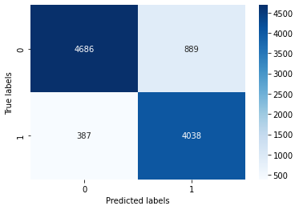

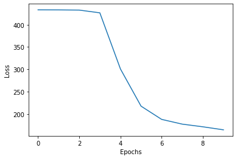

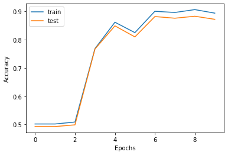

```python
NEURONS = 64
train_loader, test_loader = generate_data_loader()
model = create_model([
    MyLinear_mod(3000,NEURONS),
    MyReLU_mod(),
    MyLinear_mod(NEURONS, NEURONS),
    MyReLU_mod(),
    MyLinear_mod(NEURONS, NEURONS),
    MyReLU_mod(),
    MyLinear_mod(NEURONS, 1),
    nn.Sigmoid()
])

train_losses, test_accuracys, train_accuacys = train_model(model, train_loader, test_loader)
```

As you can see our model reaches test accuracy 87% and train accuracy 90%.

*Why initializing weights and bias with zeros is not a good idea?*

If we initialize all weights and biases with zero values, the neural network will not be able to learn effectively. This is because all neurons in the same layer will have the same output and the gradients of the loss with respect to the weights and biases will have the same value for all neurons. As a result, all neurons will update their weights and biases by the same amount during backpropagation, and the network will not be able to distinguish between different features in the input data.

#### Effect of Different Learning Rates

We test the same model with learning rate = 0.01, 0.1, 1

```
Test results:
 F1:0.33, Precision:0.75, Recall:0.50 Accuracy:0.4927
Train results:
 F1:0.33, Precision:0.75, Recall:0.50 Accuracy:0.501825
```

```
Test results:
 F1:0.33, Precision:0.75, Recall:0.50 Accuracy:0.4927
Train results:
 F1:0.33, Precision:0.75, Recall:0.50 Accuracy:0.501825
```

```
Test results:
 F1:0.33, Precision:0.75, Recall:0.50 Accuracy:0.4927
Train results:
 F1:0.33, Precision:0.75, Recall:0.50 Accuracy:0.501825
```

```
Test results:
 F1:0.33, Precision:0.75, Recall:0.50 Accuracy:0.4927
Train results:
 F1:0.33, Precision:0.75, Recall:0.50 Accuracy:0.501825
```

```
Test results:
 F1:0.33, Precision:0.75, Recall:0.50 Accuracy:0.4927
Train results:
 F1:0.33, Precision:0.75, Recall:0.50 Accuracy:0.501825
```

```
Test results:
 F1:0.33, Precision:0.75, Recall:0.50 Accuracy:0.4927
Train results:
 F1:0.33, Precision:0.75, Recall:0.50 Accuracy:0.50185
```

```
Test results:
 F1:0.33, Precision:0.75, Recall:0.50 Accuracy:0.4927
Train results:
 F1:0.33, Precision:0.75, Recall:0.50 Accuracy:0.501825
```

```
Test results:
 F1:0.33, Precision:0.75, Recall:0.50 Accuracy:0.4927
Train results:
 F1:0.33, Precision:0.75, Recall:0.50 Accuracy:0.501825
```

```
Test results:
 F1:0.33, Precision:0.75, Recall:0.50 Accuracy:0.4927
Train results:
 F1:0.33, Precision:0.75, Recall:0.50 Accuracy:0.501825
```

```
Test results:
 F1:0.33, Precision:0.75, Recall:0.50 Accuracy:0.4927
Train results:
 F1:0.33, Precision:0.75, Recall:0.50 Accuracy:0.501825
```

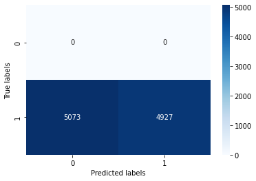

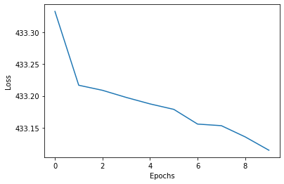

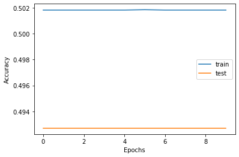

```python
NEURONS = 64
train_loader, test_loader = generate_data_loader()
model = create_model([
    MyLinear_mod(3000,NEURONS),
    MyReLU_mod(),
    MyLinear_mod(NEURONS, NEURONS),
    MyReLU_mod(),
    MyLinear_mod(NEURONS, NEURONS),
    MyReLU_mod(),
    MyLinear_mod(NEURONS, 1),
    nn.Sigmoid()
])

train1, test1, losses1 = train_model(model, train_loader, test_loader, learning_rate=0.01)
```

```
Test results:
 F1:0.34, Precision:0.75, Recall:0.50 Accuracy:0.5073
Train results:
 F1:0.33, Precision:0.75, Recall:0.50 Accuracy:0.498175
```

```
Test results:
 F1:0.75, Precision:0.75, Recall:0.75 Accuracy:0.7485
Train results:
 F1:0.75, Precision:0.76, Recall:0.75 Accuracy:0.75475
```

```
Test results:
 F1:0.54, Precision:0.76, Recall:0.61 Accuracy:0.6023
Train results:
 F1:0.54, Precision:0.77, Recall:0.61 Accuracy:0.610925
```

```
Test results:
 F1:0.81, Precision:0.85, Recall:0.82 Accuracy:0.8148
Train results:
 F1:0.82, Precision:0.85, Recall:0.83 Accuracy:0.827225
```

```
Test results:
 F1:0.87, Precision:0.87, Recall:0.87 Accuracy:0.8732
Train results:
 F1:0.89, Precision:0.89, Recall:0.89 Accuracy:0.889975
```

```
Test results:
 F1:0.88, Precision:0.88, Recall:0.88 Accuracy:0.8804
Train results:
 F1:0.90, Precision:0.90, Recall:0.90 Accuracy:0.899425
```

```
Test results:
 F1:0.88, Precision:0.88, Recall:0.88 Accuracy:0.8807
Train results:
 F1:0.90, Precision:0.90, Recall:0.90 Accuracy:0.9039
```

```
Test results:
 F1:0.88, Precision:0.88, Recall:0.88 Accuracy:0.882
Train results:
 F1:0.91, Precision:0.91, Recall:0.91 Accuracy:0.906425
```

```
Test results:
 F1:0.88, Precision:0.88, Recall:0.88 Accuracy:0.8763
Train results:
 F1:0.90, Precision:0.91, Recall:0.90 Accuracy:0.904975
```

```
Test results:
 F1:0.88, Precision:0.88, Recall:0.88 Accuracy:0.8795
Train results:
 F1:0.91, Precision:0.91, Recall:0.91 Accuracy:0.9098
```

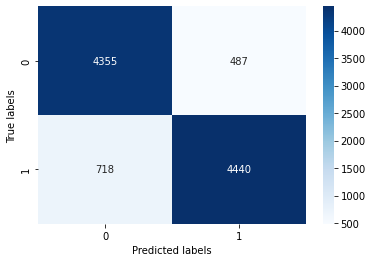

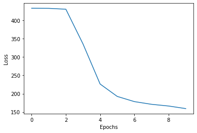

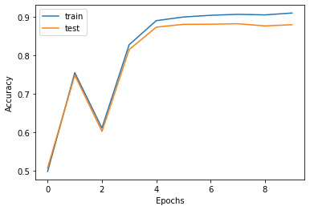

```python
NEURONS = 64
train_loader, test_loader = generate_data_loader()
model = create_model([
    MyLinear_mod(3000,NEURONS),
    MyReLU_mod(),
    MyLinear_mod(NEURONS, NEURONS),
    MyReLU_mod(),
    MyLinear_mod(NEURONS, NEURONS),
    MyReLU_mod(),
    MyLinear_mod(NEURONS, 1),
    nn.Sigmoid()
])

train2, test2, losses2 = train_model(model, train_loader, test_loader, learning_rate=0.1)
```

```
Test results:
 F1:0.34, Precision:0.75, Recall:0.50 Accuracy:0.5073
Train results:
 F1:0.33, Precision:0.75, Recall:0.50 Accuracy:0.498175
```

```
Test results:
 F1:0.34, Precision:0.75, Recall:0.50 Accuracy:0.5073
Train results:
 F1:0.33, Precision:0.75, Recall:0.50 Accuracy:0.498175
```

```
Test results:
 F1:0.84, Precision:0.86, Recall:0.85 Accuracy:0.8445
Train results:
 F1:0.85, Precision:0.86, Recall:0.85 Accuracy:0.851975
```

```
Test results:
 F1:0.85, Precision:0.86, Recall:0.85 Accuracy:0.8546
Train results:
 F1:0.86, Precision:0.88, Recall:0.86 Accuracy:0.86465
```

```
Test results:
 F1:0.87, Precision:0.88, Recall:0.87 Accuracy:0.8702
Train results:
 F1:0.89, Precision:0.89, Recall:0.89 Accuracy:0.89125
```

```
Test results:
 F1:0.83, Precision:0.86, Recall:0.84 Accuracy:0.8348
Train results:
 F1:0.85, Precision:0.88, Recall:0.85 Accuracy:0.851575
```

```
Test results:
 F1:0.87, Precision:0.88, Recall:0.87 Accuracy:0.8719
Train results:
 F1:0.90, Precision:0.90, Recall:0.90 Accuracy:0.899925
```

```
Test results:
 F1:0.88, Precision:0.88, Recall:0.88 Accuracy:0.8794
Train results:
 F1:0.91, Precision:0.91, Recall:0.91 Accuracy:0.905975
```

```
Test results:
 F1:0.87, Precision:0.88, Recall:0.87 Accuracy:0.8721
Train results:
 F1:0.90, Precision:0.91, Recall:0.90 Accuracy:0.90195
```

```
Test results:
 F1:0.88, Precision:0.88, Recall:0.88 Accuracy:0.8774
Train results:
 F1:0.91, Precision:0.91, Recall:0.91 Accuracy:0.90615
```

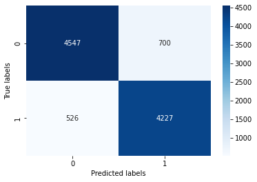

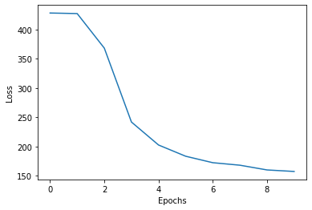

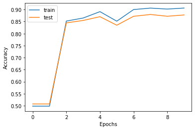

```python
NEURONS = 64
train_loader, test_loader = generate_data_loader()
model = create_model([
    MyLinear_mod(3000,NEURONS),
    MyReLU_mod(),
    MyLinear_mod(NEURONS, NEURONS),
    MyReLU_mod(),
    MyLinear_mod(NEURONS, NEURONS),
    MyReLU_mod(),
    MyLinear_mod(NEURONS, 1),
    nn.Sigmoid()
])

train3, test3, losses3 = train_model(model, train_loader, test_loader, learning_rate=1)
```

Now we plot these three models together:

Increasing the learning rate by a factor of 10 can cause the model to converge more quickly, but it can also cause the training process to become unstable and result in the model overshooting the optimal weights.(If we train that model more than once, sometimes it doesn't grow well and get stuck at below 60%)

Decreasing the learning rate by a factor of 10 means that the model will take smaller steps in the weight space during each update, which can cause the optimization process to converge more slowly but more accurately(for this model 0.01 is too slow!)

So in general, I think 0.1 for learning rate was the best option.

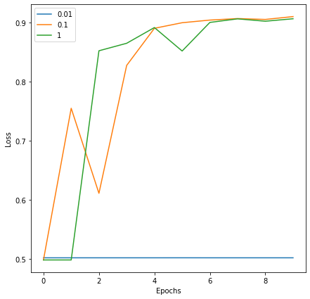

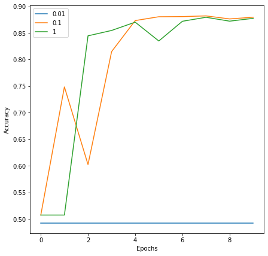

```python
plt.figure(figsize=(7, 7))
plt.plot(losses1)
plt.plot(losses2)
plt.plot(losses3)
plt.xlabel('Epochs')
plt.ylabel('Loss')
plt.legend(["0.01", "0.1", "1"])
plt.show()

plt.figure(figsize=(7, 7))
plt.plot(test1)
plt.plot(test2)
plt.plot(test3)
plt.xlabel('Epochs')
plt.ylabel('Accuracy')
plt.legend(["0.01", "0.1", "1"])
plt.show()
```